# Lab 2 Solution Proposal

February 2, 2018

## Setup

We begin by loading the packages we will be using.

```r
library(tidyverse)
library(haven)
library(stargazer)
library(lubridate)
library(AER)
```

## Warming up at the Fulton fish market

We now proceed by loading the dataset using the `read_dta` function from the haven package (part of the tidyverse).

```r
fishmarket <- read_dta("fishmarket.dta")
```

### Present and understand your data

#### 1.

As in the previous lab, we can make a table of summary statistics using the stargazer package.

```r
summarydata <- fishmarket %>%
    select(price,quan,stormy,mixed)
stargazer(as.data.frame(summarydata),
          type = "text",
          covariate.labels = c("Price",
                               "Quantity",
                               "Stormy Weather",
                               "Mixed Weather"))
```

```
=========================================================
Statistic       N    Mean    St. Dev.    Min      Max
---------------------------------------------------------
Price          111   0.885     0.335    0.330    1.943
Quantity       111 6,334.667 4,040.120 490.000 21,619.990
Stormy Weather 111   0.288     0.455      0        1
Mixed Weather  111   0.306     0.463      0        1
---------------------------------------------------------
```

#### 2.

The date variable is not in a format we want to work with at the moment, so we need to fix that. THe date variable is currently in the format year, month, day (numeric with YYMMDD), so we can format it using the function `ymd` from the lubridate package (we just replace the current date variable with the new one as we have no use for the old one).

```r
fishmarket <- fishmarket %>%
    mutate(date=ymd(date))
```

Now we can plot the quantity sold per day. A step-plot (`geom_step`) works well in this instance, making apparent the changes from date to date. In some instances, we might want to specify how the markers on the axes should be formatted. `ggplot` will usually do something sensible, but sometimes we can improve the figure by providing more detailed instructions. Here, we specify that the x-axis should be formatted as a date (`scale_x_date`) with a monthly resolution.

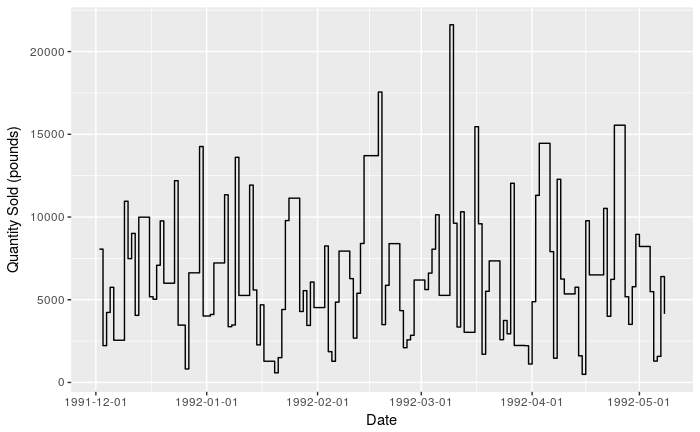

```r
ggplot(data=fishmarket,aes(x=date,y=quan)) +
    geom_step() +
    scale_x_date(date_breaks = "1 month") +
    labs(x="Date",y="Quantity Sold (pounds)")
```

We can also plot the price per unit each day.

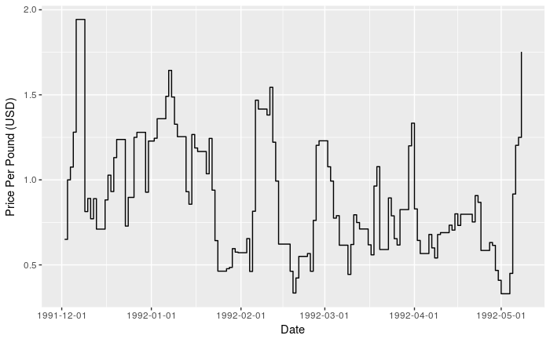

```r
ggplot(data=fishmarket,aes(x=date,y=price)) +
    geom_step() +
    scale_x_date(date_breaks = "1 month") +
    labs(x="Date",y="Price Per Pound (USD)")
```

It might be easier to see how prices and quantities vary together if we place the two plots in one figure, though this requires a bit more effort to get to work “straight out of the box”:

```
attributes are not identical across measure variables;
they will be dropped
```

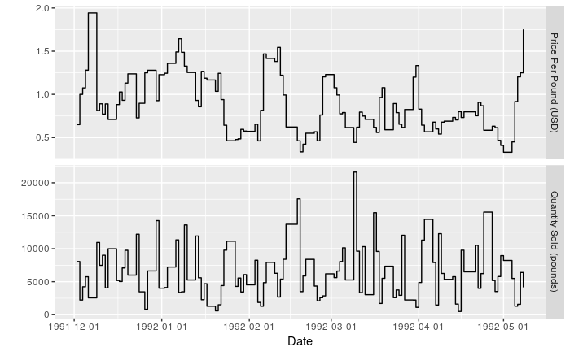

```r
fishmarket %>% select(date, price, quan) %>%
  gather(key = 'variable', value = 'value', -date) %>%
  ggplot(aes(x=date, y=value)) +
  geom_step() +
  facet_grid(variable ~ ., scales = 'free_y',
             labeller = as_labeller(c('price'='Price Per Pound (USD)', 'quan'='Quantity Sold (pounds)'))
             ) +
  scale_x_date(date_breaks = "1 month") +
  labs(x = 'Date', y = '')
```

#### 3.

We now regress quantity on price and make a regression table using stargazer. By using the options `covariate.labels`, we can change the display of variable names in the table, while `dep.var.labels` can be used to change the header over each column.

```r
quan_price_ols <- lm(quan ~ price,
                     data=fishmarket)
stargazer(quan_price_ols,
          type="text",
          covariate.labels = c("Price"),
          dep.var.labels = c("Quantity Sold"),
          keep.stat = c("n","rsq"))
```

```
========================================
                 Dependent variable:
             ---------------------------
                    Quantity Sold
----------------------------------------
Price               -3,709.017***
                     (1,098.750)

Constant            9,615.382***
                     (1,038.695)

----------------------------------------
Observations             111
R2                      0.095
========================================
Note:        *p<0.1; **p<0.05; ***p<0.01
```

The sign is negative, which is what we would expect in demand. Still, this is a market system, where we expect unobserved demand factors to influence price as well. Make sure you understand how this could arise (unobserved demand factors shifting the demand curve along the supply curve, thereby changing price, and/or unobserved demand factors being correlated with unobserved factors shifting supply).

The results are probably easier to read if we scale quantity to 1000 pounds and set the number of digits after decimal to two:

```r
quant_price_ols <- lm(quan / 1000 ~ price,
                      data=fishmarket)
stargazer(quant_price_ols,
          type="text",
          digits = 2,
          covariate.labels = c("Price"),
          dep.var.labels = c("Quantity Sold (1000 pounds)"),
          keep.stat = c("n","rsq"))
```

```
========================================
                 Dependent variable:
             ---------------------------
             Quantity Sold (1000 pounds)
----------------------------------------
Price                 -3.71***
                       (1.10)

Constant               9.62***
                       (1.04)

----------------------------------------
Observations             111
R2                      0.09
========================================
Note:        *p<0.1; **p<0.05; ***p<0.01
```

Note that we can also create a table which looks nicer in the html output of the notebook by specifying the option `results='asis'` for the chunk (necessary for the final output to display the table correctly) and `type=html` for stargazer (though it becomes hard to see the results when working with the notebook directly). (Optionally, one can also set the option `style` to give the table a particular format, as shown here)

```r
stargazer(quant_price_ols,
          type="html",
          style='aer',
          digits = 2,
          covariate.labels = c("Price"),
          dep.var.labels = c("Quantity Sold (1000 pounds)"),
          keep.stat = c("n","rsq"))
```

|  | Quantity Sold (1000 pounds) |
| --- | --- |
| Price | -3.71*** |
|  | (1.10) |
| Constant | 9.62*** |
|  | (1.04) |
| Observations | 111 |
| R<sup>2</sup> | 0.09 |
| *Notes:* | ***Significant at the 1 percent level. |
|  | **Significant at the 5 percent level. |
|  | *Significant at the 10 percent level. |

### Assessing and understanding IV

#### 4.

To make this plot, we have to generate a variable showing if the weather is stormy, mixed or clear at sea.

```r
fishmarket <- fishmarket %>%
    mutate(weather=ifelse(stormy==1,"High wind and waves",
                          ifelse(mixed==1,"Mixed wind and waves",
                                 NA)))
```

We can now make the plot. This involves invoking the `fill` aesthetic of ggplot, which will make columns of separate color for the weather-type. The option `alpha` tells ggplot how opaque or transparent we want the element to be, where a lower value means more transparent, which can help with making other features easier to see (like the price series here). We filter out the `NA`-values from the variable *weather* using the `filter`-function (from the tidyverse package dplyr), so that these do not feature with a fill-color or in the legend of the plot. `scale_fill_brewer` allows us to choose the color scheme for the `fill`-aesthetic that we’ve chosen, which we optionally can provide with a name, otherwise the default is the variable name (weather, with lower-case initial).

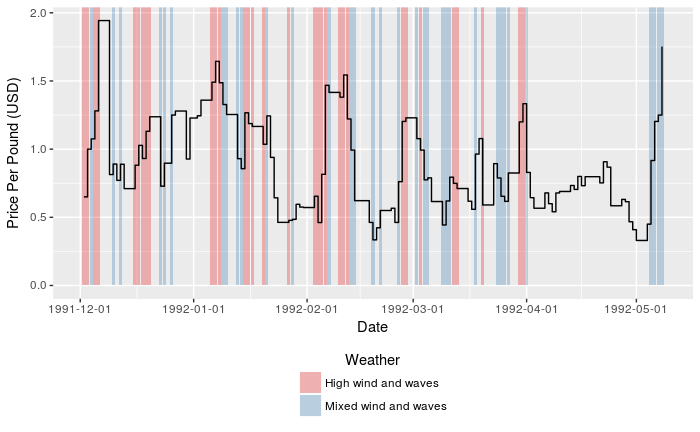

```r
ggplot(data=fishmarket,aes(x=date,y=price)) +
    geom_col(data=filter(fishmarket,!is.na(weather)),
             aes(y=Inf,fill=weather),
             alpha=0.3) +
    geom_step() +
    scale_fill_brewer(name = "Weather", palette = "Set1") +
    scale_x_date(date_breaks = "1 month") +
    labs(x="Date",y="Price Per Pound (USD)") +
    theme(legend.position = "bottom",
          legend.direction = "vertical",
          legend.title.align = 0.5)
```

From this plot, it seems quite clear that prices tend to be higher when the weather at sea is worse (though not without variation). This is a nice way of inspecting the instrument we will be using in this setting (indicators for events over time). We could also make the same plot using quantities instead of prices to verify that the shifts in prices from weather conditions seem to affect demand as well.

#### 5.

We estimate the regression equations and present them in a table using stargazer.

```r
price_stormy_ols <- lm(price ~ stormy,
                       data=fishmarket)
quan_stormy_ols <- lm(quan / 1000 ~ stormy,
                      data=fishmarket)
stargazer(price_stormy_ols,quan_stormy_ols,
          type="text",
          covariate.labels = c("Stormy Weather"),
          dep.var.labels = c("Price","Quantity"),
          keep.stat = c("n","rsq"),
          digits=3,
          digit.separator ="")
```

```
===========================================
                   Dependent variable:
               ----------------------------
                   Price        Quantity
                    (1)            (2)
-------------------------------------------
Stormy Weather    0.311***      -2.174***
                  (0.064)        (0.825)

Constant          0.795***      6.961***
                  (0.034)        (0.443)

-------------------------------------------
Observations        111            111
R2                 0.179          0.060
===========================================
Note:           *p<0.1; **p<0.05; ***p<0.01
```

Constants gives the average value of price and quantity when weather is not stormy, while the coefficient on stormy is the change in the average when the weather is stormy. Average value when stormy is then “constant + coeff. stormy”. We can also calculate the avarege values using R.

```r
avg_by_stormy <- fishmarket %>%
    group_by(stormy) %>%
    summarize("Average Price" = round(mean(price), 3),
              "Average Quantity" = round(mean(quan / 1000), 3))
avg_by_stormy
```

| stormy | Average Price | Average Quantity |
| --- | --- | --- |
| 0 | 0.795 | 6.961 |
| 1 | 1.106 | 4.787 |

We can calculate the difference by picking out the row of the stored averages where wheather is stormy and not (using `filter`) and subtracting:

```r
filter(avg_by_stormy, stormy==1) - filter(avg_by_stormy, stormy==0)
```

| stormy | Average Price | Average Quantity |
| --- | --- | --- |
| 1 | 0.311 | -2.174 |

which we see are equal to the coefficients on *Stormy weather* in the regression table.

We can calculate the ratio of changes in several ways, for instance by using the coefficients from the regressions:

```r
#Ratio of changes
quan_stormy_ols$coefficients['stormy'] / price_stormy_ols$coefficients['stormy']
```

```
   stormy
-6.982369
```

#### 6.

We begin by estimating the instrumental variables equation as well as the first stage equation. Note the use of `I()` in the formula for the IV regression. Previously, we’ve just written `quan / 1000` whenever we wanted to scale quantity to thousands, but not all regression functions directly accepts such expressions modifying the values of a variable. The special function `I()` solves this, such that we can do calculations with a variable for most regression functions without having to create and store new variables for every instance (should be used for instance when we want to include squared terms, e.g., `I(x^2)`).

```r
quan_price_iv <- ivreg(I(quan / 1000) ~ price | stormy,
                       data=fishmarket,
                       x=TRUE)
quan_price_first <- lm(price ~ stormy,
                       data=fishmarket)
stargazer(quan_price_first,quan_price_iv,
          type="html",
          style="aer",
          covariate.labels = c("Stormy Weather","Price"),
          dep.var.labels = c("Price","Quantity"),
          column.labels = c("(First Stage)","(Second Stage)"),
          model.names = FALSE,
          digits = 2,
          notes = ("Price was instrumented for using an indicator for stormy weather"),
          notes.align = "l",
          keep.stat = c("n","rsq","F"))
```

|  | Price | Quantity |
| --- | --- | --- |
|  | (First Stage) | (Second Stage) |
|  | (1) | (2) |
| Stormy Weather | 0.31*** |  |
|  | (0.06) |  |
| Price |  | -6.98** |
|  |  | (2.70) |
| Constant | 0.79*** | 12.51*** |
|  | (0.03) | (2.42) |
| Observations | 111 | 111 |
| R<sup>2</sup> | 0.18 | 0.02 |
| F Statistic | 23.72*** (df = 1; 109) |  |
| *Notes:* | ***Significant at the 1 percent level. |  |
|  | **Significant at the 5 percent level. |  |
|  | *Significant at the 10 percent level. |  |
|  | Price was instrumented for using an indicator for stormy weather |  |

See that the coefficient exactly equals the ratio of the coefficients from before. This is a way of formulating the IV-regression, where the coefficient in the “reduced form” (variable of interest on IV) is divided by the coefficient in the “first stage” (endogenous variable on IV). See the lecture notes for further explanation (“IV from exogeneity”).

We could be worried that the weather at sea is correlated with weather on land, which could affect demand for fish. We could test whether including rainy and cold (on shore) as controls affects the estimates.

```r
quan_price_first_controls <- lm(price ~ stormy + rainy + cold,
                                data=fishmarket)
quan_price_reduced_controls <- lm(quan / 1000 ~ stormy + rainy + cold,
                                  data=fishmarket)
quan_price_iv_controls <- ivreg(I(quan / 1000) ~ price + rainy + cold | rainy + cold + stormy,
                                data=fishmarket)
stargazer(quan_price_first_controls,quan_price_reduced_controls,quan_price_iv_controls,
          type="html",
          style="aer",
          keep.stat=c("n","rsq","F"),
          covariate.labels = c("Stormy Weather","Price","Rainy Weather","Cold Weather"),
          dep.var.labels = c("Price","Quantity"),
          model.names = FALSE,
          digits = 2,
          column.labels = c("(First Stage)","(Reduced Form)","(Second Stage)"))
```

|  | Price | Quantity | I(quan/1000) |
| --- | --- | --- | --- |
|  | (First Stage) | (Reduced Form) | (Second Stage) |
|  | (1) | (2) | (3) |
| Stormy Weather | 0.29*** | -2.03** |  |
|  | (0.07) | (0.90) |  |
| Price |  |  | -7.07** |
|  |  |  | (3.22) |
| Rainy Weather | -0.03 | 0.55 | 0.35 |
|  | (0.08) | (1.03) | (1.05) |
| Cold Weather | 0.06 | -0.43 | -0.00 |
|  | (0.06) | (0.82) | (0.93) |
| Constant | 0.78*** | 7.05*** | 12.53*** |
|  | (0.04) | (0.56) | (2.65) |
| Observations | 111 | 111 | 111 |
| R<sup>2</sup> | 0.19 | 0.06 | 0.02 |
| F Statistic (df = 3; 107) | 8.16*** | 2.46* |  |
| *Notes:* | ***Significant at the 1 percent level. |  |  |
|  | **Significant at the 5 percent level. |  |  |
|  | *Significant at the 10 percent level. |  |  |

We observe some small changes in the first stage coefficients, though considering the size of the sample this could very well be put on the quota for statistical error, and none of the included coefficients are significant (or large, compared to our regressor of interest [stormy]).

The second stage coefficients are virtually unchanged, though the standard error is quite a bit larger (this might happen when we include irrelevant variables). This should make us feel somewhat better about the instrument, though we can’t completely rule out other potential worries (try to come up with a couple more).

#### 7.

```r
quan_day_ols <- lm(quan / 1000 ~ mon + tue + wed + thu,
                   data=fishmarket)
stormy_day_ols <- lm(stormy ~ mon + tue + wed + thu,
                     data=fishmarket)
quan_price_day_first <- lm(price ~ stormy + mon + tue + wed + thu,
                              data=fishmarket)
quan_price_iv_day_iv <- ivreg(I(quan / 1000) ~ price + mon + tue + wed + thu | stormy +
                                  mon + tue + wed + thu,
                              data=fishmarket)
stargazer(quan_day_ols,stormy_day_ols,quan_price_day_first,quan_price_iv_day_iv,
          type="text",
          dep.var.labels = c("Quantity","Stormy Weather","Price","Quantity"),
          covariate.labels = c("Stormy Weather","Price","Monday","Tuesday","Wednesday","Thursday"),
          model.names = FALSE,
          digits = 2,
          column.labels = c("(OLS)","(OLS)","(First Stage)","(Second Stage)"),
          keep.stat = c("n","rsq","F"))
```

```
============================================================================================
                                            Dependent variable:
               -----------------------------------------------------------------------------
                     Quantity          Stormy Weather           Price            Quantity
                       (OLS)               (OLS)            (First Stage)     (Second Stage)
                        (1)                 (2)                  (3)               (4)
--------------------------------------------------------------------------------------------
Stormy Weather                                                 0.32***
                                                               (0.06)

Price                                                                            -7.36***
                                                                                  (2.51)

Monday                 0.99                 0.12                -0.14              0.23
                      (1.16)               (0.14)              (0.09)             (1.18)

Tuesday               -2.24*                0.04                -0.07            -2.61**
                      (1.13)               (0.14)              (0.09)             (1.14)

Wednesday             -2.72**              -0.02                -0.05            -3.17***
                      (1.16)               (0.14)              (0.09)             (1.17)

Thursday               0.20                 0.00                0.01               0.25
                      (1.13)               (0.14)              (0.09)             (1.13)

Constant              7.08***             0.26***              0.84***           13.89***
                      (0.80)               (0.10)              (0.07)             (2.45)

--------------------------------------------------------------------------------------------
Observations            111                 111                  111               111
R2                     0.13                 0.01                0.20               0.14
F Statistic    3.87*** (df = 4; 106) 0.32 (df = 4; 106) 5.38*** (df = 5; 105)
============================================================================================
Note:                                                            *p<0.1; **p<0.05; ***p<0.01
```

Not a lot of change in the coefficient of interest (at least compared to the standard error). This follows from day of week not being correlated with wether the weather is stormy or not - thus we would believe that the day of week is not a source of omitted variable bias affecting the instrument in the IV-regression. The change in the coefficient on stormy in the first stage is also minor, since stormy is basically uncorrelated with day of week (which is probably not very surprising).

### Estimating supply and demand

#### 8. Extra:

##### (a)

We begin by generating the indicator variable.

```r
fishmarket <- fishmarket %>%
    mutate(lowdemand=factor(tue + wed))
```

Now we proceed by estimating the equations.

```r
price_stormy_lowdemand_ols <- lm(price ~ stormy + lowdemand,
                             data=fishmarket)
quan_stormy_lowdemand_ols <- lm(quan / 1000 ~ stormy + lowdemand,
                                data=fishmarket)
stargazer(price_stormy_lowdemand_ols,quan_stormy_lowdemand_ols,
          type="text",
          digits = 2,
          dep.var.labels = c("Price","Quantity"),
          covariate.labels = c("Stormy Weather","Low Demand Day"),
          keep.stat = c("n","rsq"))
```

```
===========================================
                   Dependent variable:
               ----------------------------
                   Price        Quantity
                    (1)            (2)
-------------------------------------------
Stormy Weather    0.31***       -2.26***
                   (0.06)        (0.77)

Low Demand Day     -0.02        -2.90***
                   (0.06)        (0.71)

Constant          0.80***        8.14***
                   (0.04)        (0.51)

-------------------------------------------
Observations        111            111
R2                  0.18          0.18
===========================================
Note:           *p<0.1; **p<0.05; ***p<0.01
```

We see that quantity is significantly affected by low-demand days, while price is basically unaffected (also statistically insignificant). This seems to imply that, if low-demand days are not otherwise affecting supply (not excluded or not exogenous), then higher quantity demanded does not necessarily imply increased prices. If we were to try to instrument price in an equation for quantity supplied here, we would get a very erratic result, as the instrument is not actually passing a relevance test:

```r
quan_price_lowdemand_iv <- ivreg(I(quan / 1000) ~ price + stormy | lowdemand + stormy,
                                 data=fishmarket)
stargazer(quan_price_lowdemand_iv,
          type="html",
          dep.var.labels = "Quantity",
          digits = 2,
          covariate.labels = c("Price","Stormy Weather"),
          keep.stat = c("n","rsq"))
```

|  | *Dependent variable:* |
| --- | --- |
|  | Quantity |
| Price | 158.53 |
|  | (526.65) |
| Stormy Weather | -51.53 |
|  | (164.30) |
| Constant | -119.03 |
|  | (418.60) |
| Observations | 111 |
| R<sup>2</sup> | -147.31 |
| *Note:* | p<0.1; p<0.05; p<0.01 |

At face value, the coefficient basically says supply explodes if price were to increase. The standard error also tells us that we cannot rule out the coefficient taking almost any value. This is one of those cases where we see from the results that something is off, due to a failure of relevance. Sometimes this is not so clear without inspecting the first stage, as the IV estimator has very bad properties in these cases, and could just as well give results which seems apparently okay.

However, we could estimate the inverse supply relation as the price for fish as a function of the market equilibrium quantity, as the instrument is relevant for quantity. By remembering the IV-mechanics, we could already tell what the result is going to be from the two coefficients estimated above.

##### (b)

We estimate the first and second stage equations.

```r
price_quan_first <- lm(I(quan / 1000) ~ lowdemand + stormy,
                       data=fishmarket)
price_quan_iv <- ivreg(price ~ I(quan / 1000) + stormy | lowdemand + stormy,
                       data=fishmarket)
stargazer(price_quan_first,price_quan_iv,
          type="text",
          dep.var.labels = c("Quantity","Price"),
          covariate.labels = c("Low Demand Day","Quantity","Stormy Weather"),
          model.names = FALSE,
          digits = 2,
          column.labels = c("(First Stage)","(Second Stage)"),
          keep.stat = c("n","rsq","F"))
```

```
====================================================
                        Dependent variable:
               -------------------------------------
                      Quantity            Price
                   (First Stage)      (Second Stage)
                        (1)                (2)
----------------------------------------------------
Low Demand Day        -2.90***
                       (0.71)

Quantity                                   0.01
                                          (0.02)

Stormy Weather        -2.26***           0.33***
                       (0.77)             (0.08)

Constant              8.14***            0.75***
                       (0.51)             (0.15)

----------------------------------------------------
Observations            111                111
R2                      0.18               0.14
F Statistic    12.21*** (df = 2; 108)
====================================================
Note:                    *p<0.1; **p<0.05; ***p<0.01
```

The first stage tells us that the instrument does quite well on the relevance test. It shifts the endogenous regressor by a fair amount, the standard error is reasonably low (compared to the small sample size here), and the F-statistic for the regression is 12.21, which passes the heuristic test.

The coefficient on quantity in this price regression tells us that price on the supply side is barely responding to quantity. This implies a close to perfectly elastic supply curve, which is shifted up or down by weather conditions (and other unobserved shocks).

This could be reasonable if, for instance, the fishermen have a pretty good idea about what demand is going to be, and the next fish is basically just as costly to catch as the previous one (constant marginal cost), though the cost depends on the conditions (weather, and likely other, unmodelled ones, such as the location of the fish on a given day).

##### (c)

We want to extract the supply and demand equations from the estimated results. We begin with supply. Note that we need to refer to the quantity variable with the expression syntax used in the formula (also note that it would not have been wrong to rescale the quantity variable in the dataset for the whole exercise instead).

```r
price_quan_iv <- ivreg(price ~ I(quan / 1000) + stormy | lowdemand + stormy,
                       data=fishmarket)
intercept_supply <- price_quan_iv$coefficients["(Intercept)"]
slope_supply <- price_quan_iv$coefficients["I(quan/1000)"]
shift_supply <- price_quan_iv$coefficients["stormy"]
```

We can now generate the supply curves for stormy and non-stormy days as functions (learning to write your own functions can be very useful in R):

```r
supplycurve_nonstormy <- function(x) {
    intercept_supply + slope_supply*x
}
supplycurve_stormy <- function(x) {
    intercept_supply + shift_supply + slope_supply*x

}
```

And now demand.

```r
quan_price_lowdemand_iv <- ivreg(I(quan / 1000) ~ price + lowdemand | stormy + lowdemand,
                                 data=fishmarket)
intercept_demand <- quan_price_lowdemand_iv$coefficients["(Intercept)"]
slope_demand <- quan_price_lowdemand_iv$coefficients["price"]
shift_demand <- quan_price_lowdemand_iv$coefficients["lowdemand1"]
```

To make the plotting easier, we solve the demand functions for price (since the plotting function we’ll be using assumes that the function returns values for the vertical axis, given a value on the horizontal axis).

For high demand days:
$$\text{Demand}_{\text{high}} = \text{Intercept} + \text{Slope}\cdot\text{Price} \\
\text{Price} = -\frac{\text{Intercept}}{\text{Slope}} + \frac{1}{\text{Slope}}\cdot\text{Demand}_{\text{high}}$$

For low demand days:
$$\text{Demand}_{\text{low}} = \text{Intercept} + \text{Demand Shift} + \text{Slope}\cdot\text{Price} \\
\text{Price} = -\frac{\text{Intercept} + \text{Demand Shift}}{\text{Slope}} + \frac{1}{\text{Slope}}\cdot\text{Demand}_{\text{low}}$$

Now we store the inverted functions.

```r
demandcurve_high <- function(x) {
    -(intercept_demand/slope_demand) + x/slope_demand
}
demandcurve_low <- function(x) {
    -(intercept_demand+shift_demand)/slope_demand + x/slope_demand
}
```

We can now plot the functions.

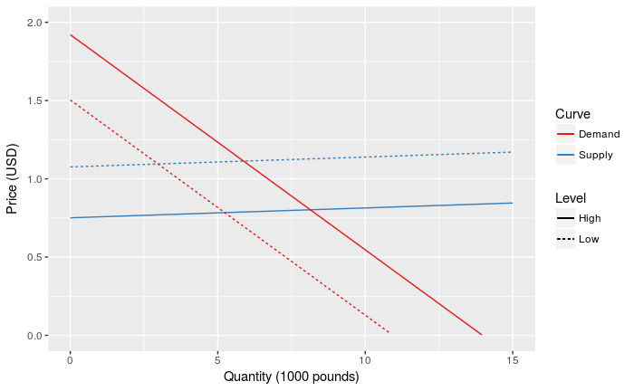

```r
ggplot(data=data.frame(x=c(0,15),y=c(0,2)),aes(x=x,y=y)) +
    stat_function(fun=supplycurve_nonstormy,
                  aes(color="Supply",linetype="High")) +
    stat_function(fun=supplycurve_stormy,
                  aes(color="Supply",linetype="Low")) +
    stat_function(fun=demandcurve_high,
                  aes(color="Demand",linetype="High")) +
    stat_function(fun=demandcurve_low,
                  aes(color="Demand",linetype="Low")) +
    scale_y_continuous(limits=c(0,2)) +
    scale_color_brewer(name="Curve",palette = "Set1") +
    scale_linetype_discrete(name="Level") +
    scale_x_continuous(breaks=seq(0,15,5)) +
    labs(x="Quantity (1000 pounds)",y="Price (USD)")
```

Now that we are done with the fish market data, we can remove all the objects we have in memory.

```r
rm(list=ls())
```

## Nord pool spot: The electricity wholesale market

We can now load the Nord pool data.

```r
elmarket <- read_csv("elmarket.csv")
```

### Data Wrangling

#### 1.

We need to load the population datasets.

```r
norpop <- read_csv("norpop.csv",col_names = FALSE)
colnames(norpop) <- c("city","population")
swepop <- read_csv("swepop.csv",col_names = FALSE)
colnames(swepop) <- c("city","population")
```

```r
tempdata <- elmarket %>%
    select(-c(price,volume,hydrores)) %>%
    gather(key="city",value="temperature",-time)
```

```r
nortempdata <- inner_join(x=tempdata,y=norpop,by=c("city"="city"))
nortempdata <- nortempdata %>%
    group_by(time) %>%
    summarize(nortemp=weighted.mean(temperature,w=population))
swetempdata <- inner_join(x=tempdata,y=swepop,by=c("city"="city"))
swetempdata <- swetempdata %>%
    group_by(time) %>%
    summarize(swetemp=weighted.mean(temperature,w=population))
elmarket <- left_join(x=elmarket,y=nortempdata,
                      by=c("time"="time"))
elmarket <- left_join(x=elmarket,y=swetempdata,
                      by=c("time"="time"))
rm(tempdata,norpop,nortempdata,swepop,swetempdata)
```

### Present and understand your data

#### 2.

We first make descriptive statistics for price, volume and magazine capacity. To make volume “better” scaled, we rescale it from MWh to GWh by first dividing by 1000:

```r
elmarket <- elmarket %>% mutate(volume = volume / 1000)
```

```r
summarydata <- elmarket %>%
    select(price,volume,hydrores)
stargazer(as.data.frame(summarydata),
          type="text",
          digits = 2,
          covariate.labels = c("Price (EUR/MWh)","Volume (GWh)","Magazine Capacity (TWh)"))
```

```
==========================================================
Statistic                 N    Mean  St. Dev.  Min   Max
----------------------------------------------------------
Price (EUR/MWh)         35,060 28.90   9.64   1.14  199.97
Volume (GWh)            35,060 40.01   7.94   22.21 65.31
Magazine Capacity (TWh) 34,748 74.95  21.82   28.69 111.00
----------------------------------------------------------
```

```r
rm(summarydata)
```

We now make tables for temperatures in the Norwegian and Swedish areas. Here we utilize the fact that the Norwegian and Swedish temperatures are next to each other in the dataset, note that this way of doing it would not work if we reordered the variables. We begin with the Norwegian temperatures.

```r
nortemps <- elmarket %>%
    select(Fredrikstad:Tromso)
stargazer(as.data.frame(nortemps),
          type="text",
          digits=1)
```

```
============================================
Statistic      N    Mean St. Dev.  Min  Max
--------------------------------------------
Fredrikstad  35,060 8.6    7.1    -14.5 27.8
Oslo         35,060 7.5    8.1    -16.8 32.4
Sandefjord   35,060 7.7    7.8    -20.8 31.9
Arendal      35,060 8.8    6.4    -11.9 25.3
Kristiansand 35,060 8.2    7.2    -20.6 29.0
Stavanger    35,060 8.8    5.8    -8.1  29.8
Haugesund    35,060 8.7    5.5    -13.0 28.4
Bergen       35,060 8.8    6.0    -9.4  31.1
Trondheim    35,060 6.5    7.1    -18.7 29.9
Bodo         35,060 6.2    6.2    -14.8 28.5
Tromso       35,060 4.0    6.6    -16.8 29.7
--------------------------------------------
```

```r
rm(nortemps)
```

And now Sweden:

```r
swetemps <- elmarket %>%
    select(Goteborg:Uppsala)
stargazer(as.data.frame(swetemps),
          type="text",
          digits=1)
```

```
=========================================
Statistic   N    Mean St. Dev.  Min  Max
-----------------------------------------
Goteborg  35,060 9.5    7.3    -14.7 31.7
Malmo     35,060 9.5    7.1    -15.4 32.1
Stockholm 35,060 8.3    7.7    -16.0 31.3
Uppsala   35,060 7.6    8.2    -21.3 32.7
-----------------------------------------
```

```r
rm(swetemps)
```

#### 3.

We begin by calculating the values we will be plotting.

```r
weekdata <- elmarket %>%
    mutate(week=floor_date(time,
                           unit = "1 week",
                           week_start = 1)) %>%
    group_by(week) %>%
    summarize(meanvolume=mean(volume),
              meanprice_weighted=weighted.mean(price,w=volume),
              nortemp=mean(nortemp),
              swetemp=mean(swetemp),
              hydrores=mean(hydrores))
```

We can now plot average volume and average volume weighted price. Because these both have to do with volume we combine them in one plot. Those of you familiar with Stata will find that having a separate y axis is more complicated in ggplot2 because Hadley Wickham (a key developer of the tidyverse) thinks they are problematic.

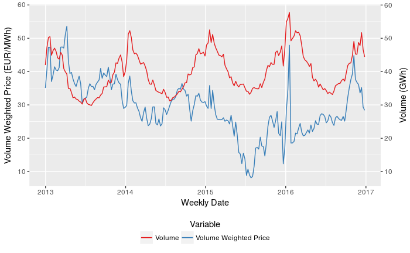

```r
ggplot(data=weekdata,aes(x=week)) +
    geom_line(aes(y=meanprice_weighted,color="Volume Weighted Price")) +
    geom_line(aes(y=meanvolume,color="Volume")) +
    scale_y_continuous(sec.axis = dup_axis(name="Volume (GWh)")) +
    scale_color_brewer(name="Variable",
                       palette = "Set1",
                       guide = guide_legend(ncol=2)) +
    labs(x="Weekly Date",y="Volume Weighted Price (EUR/MWh)") +
    theme(axis.title.y.right = element_text(angle=90),
          legend.position = "bottom",
          legend.direction = "vertical",
          legend.title.align = 0.5)
```

We proceed by plotting the average temperatures in Norway and Sweden.

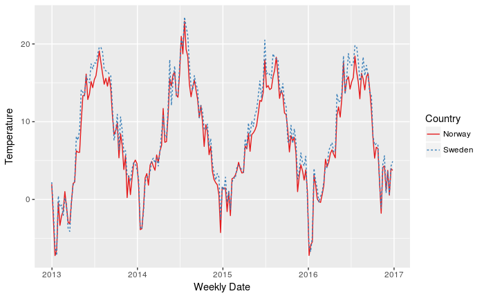

```r
weekdata %>%
    select(week,"Norway" = nortemp,"Sweden"=swetemp) %>%
    gather(key="Country",value="Temperature",-week) %>%
    ggplot(aes(x=week,y=Temperature,color=Country,linetype=Country)) +
    geom_line() +
    scale_color_brewer(palette = "Set1") +
    labs(x="Weekly Date")
```

Lastly we plot the hydro reservoir capacity.

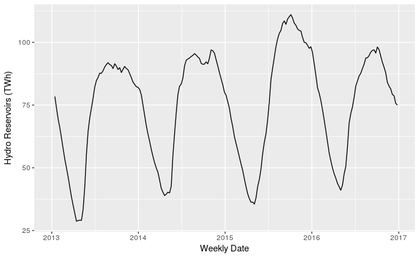

```r
ggplot(data=weekdata,aes(x=week,y=hydrores)) +
    geom_line() +
    labs(x="Weekly Date",y="Hydro Reservoirs (TWh)")
```

```r
rm(weekdata)
```

In this question one should note the strong seasonality, particularly in volume, hydro reservoir content and temperature, explain how it fits together. One should also note that prices display much less seasonality than the other series (and then, preferably try to have an explanation for this, for instance showing some seasonally adjusted series, and see whether, for instance, the residual variation in hydrores seems to correlate well with the residual variation in prices).

#### 4.

Again we begin by calculating the values we want to plot.

```r
hourdata <- elmarket %>%
    mutate(hour=hour(time)) %>%
    group_by(hour) %>%
    summarize(meanvolume=mean(volume),
              meanprice_weighted=weighted.mean(price,w=volume),
              nortemp=mean(nortemp),
              swetemp=mean(swetemp))
```

We can now plot the average volume per hour of the day.

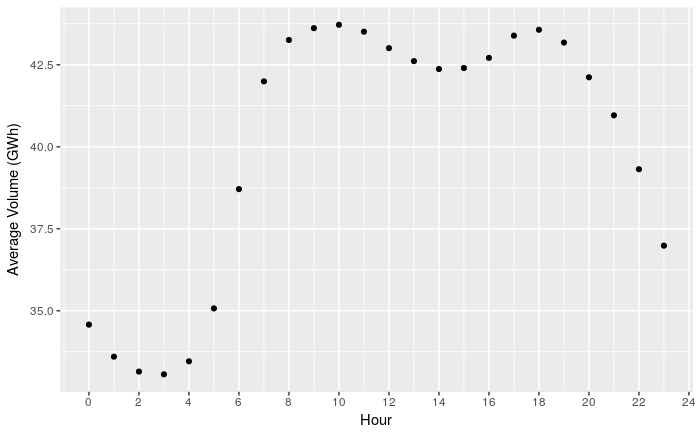

```r
ggplot(data=hourdata,aes(x=hour,y=meanvolume)) +
    geom_point() +
    labs(x="Hour",y="Average Volume (GWh)") +
    scale_x_continuous(breaks=seq(0,24,2))
```

We proceed by plotting the volume weighted price per hour of the day.

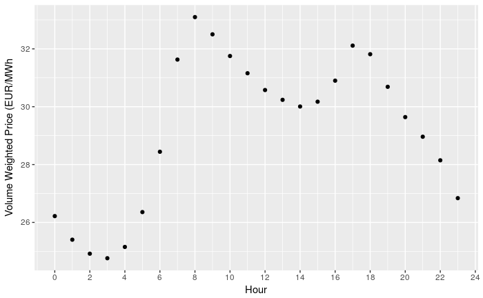

```r
ggplot(data=hourdata,aes(x=hour,y=meanprice_weighted)) +
    geom_point() +
    labs(x="Hour",y="Volume Weighted Price (EUR/MWh") +
    scale_x_continuous(breaks=seq(0,24,2))
```

Now the temperatures.

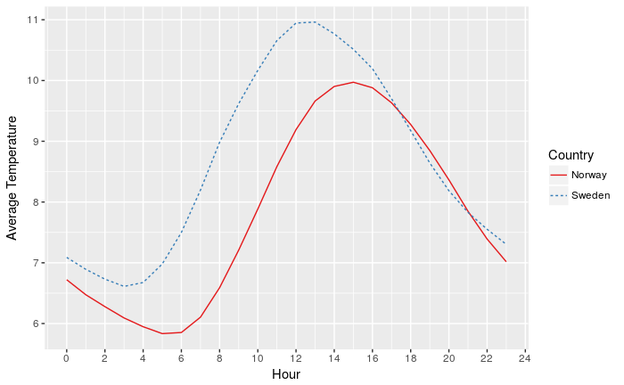

```r
hourdata %>%
    select(hour,"Norway"=nortemp,"Sweden"=swetemp) %>%
    gather(key="Country",value="Temperature",-hour) %>%
    ggplot(aes(x=hour,y=Temperature,color=Country,linetype=Country)) +
    geom_line() +
    scale_x_continuous(breaks=seq(0,24,2)) +
    labs(x="Hour",y="Average Temperature") +
    scale_color_brewer(palette = "Set1")
```

Lastly we plot the volume weighted hourly price against the the average hourly volume.

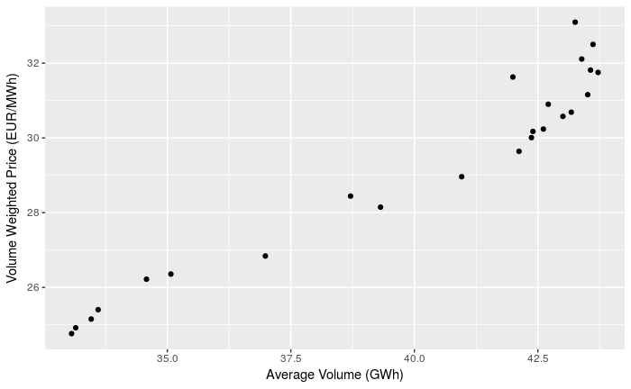

```r
ggplot(data=hourdata,aes(x=meanvolume,y=meanprice_weighted)) +
    geom_point() +
    labs(x="Average Volume (GWh)",y="Volume Weighted Price (EUR/MWh)")
```

```r
rm(hourdata)
```

Temperature follows exactly the pattern we would expect, though the interesting thing to note is that temperature is positively correlated with volume over the hours of the day, which is opposite of the negative correlation we see between temperature and volume over the seasons. We would expect the causal impact of temperature on volume to be negative (though if temperatures get very high, volumes could increase due to cooling, though this is rare in the Nordic region). This means that the dummies for hour will tend to pick up some of the effect of temperature, if temperature is not included in the regression (omitted variable formula), and vice versa for temperature. We’ll see further down how this can create a problem for IV estimation if we don’t account for this.

The scatter of average volume per hour against average price per hour tells us how volume and price are covarying when we look at the variation in them driven by hour (not controlling for other factors). This is very much related to what an IV estimation is doing, and a regression through these points would give a parameter which is close to what we get from an IV regression of volume on price instrumented by dummies for the hour of the day (there are some differences in how the different points will be weighted), and we can also see from the plot that a linear approximation to the conditional expectation of volume as a function of price will fit very well when viewed through the variation “induced” over the hours of the day. The plot is the visual IV plot (note that this does not necessarily mean that hour is a good IV - the VIV is just a device which can be useful for inspecting a potential IV), which we examine closer in task 11.

#### 5.

Many points have already been raised in the comments after 3. and 4. More directly on supply and demand factors, we would think temperature and hour of the day corresponds to demand side factors, while the hydro reservoirs will affect the supply side. The season (loosely defined - e.g., month) is a very strong predictor for the hydro reservoirs, though the season will also have a very strong influence on demand, such that we cannot necessarily put “the season” (e.g., dummies for month) as a pure supply shifter. Maybe the effect of season on demand is removed once we control for temperature, for instance if we believe that the causal path is: season -> temperature -> demand, such that controlling for temperature will break the dependence between season and demand (not that this is not testable, since if season still affects supply, we would still expect to see a change in volume - this is an exclusion restriction).

It doesn’t seem like hydro reservoir stock has an obvious relation to price when we look at the total variation in the stock, which is why we will explore residual variation (after controlling for one or more factors) in the hydro stock in 7.

#### 6.

We want to include indicators for month and year, in R this can be handled with factor variables.

```r
elmarket <- elmarket %>%
    mutate(month=factor(month(time)),
           year=factor(year(time)))
```

We proceed by estimating the equations and obtaining the residuals.

```r
volume_nortemp_fit <- lm(volume ~ nortemp,
                     data=elmarket)
volume_nortemp_res <- residuals(volume_nortemp_fit)
volume_nortemp_month_fit <- lm(volume ~ nortemp + month,
                               data=elmarket)
volume_nortemp_month_res <- residuals(volume_nortemp_month_fit)
volume_nortemp_month_year_fit <- lm(volume ~ nortemp + month + year,
                               data=elmarket)
volume_nortemp_month_year_res <- residuals(volume_nortemp_month_year_fit)
rm(volume_nortemp_fit,volume_nortemp_month_fit,volume_nortemp_month_year_fit)
```

We now add the average volume to the residuals.

```r
meanvolume <- mean(elmarket$volume)
volume_nortemp_res <- volume_nortemp_res + meanvolume
volume_nortemp_month_res <- volume_nortemp_month_res + meanvolume
volume_nortemp_month_year_res <- volume_nortemp_month_year_res + meanvolume
rm(meanvolume)
```

Now we can make the plots, beginning with the original series.

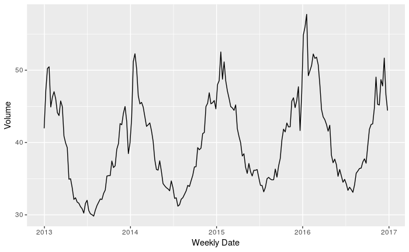

```r
elmarket %>%
    mutate(week=floor_date(time,
                           unit="1 week",
                           week_start = 1)) %>%
    group_by(week) %>%
    summarize(volume=mean(volume)) %>%
    ggplot(aes(x=week,y=volume)) +
    geom_line() +
    labs(x="Weekly Date",y="Volume")
```

```r
NA
```

And now we plot the residualized series.

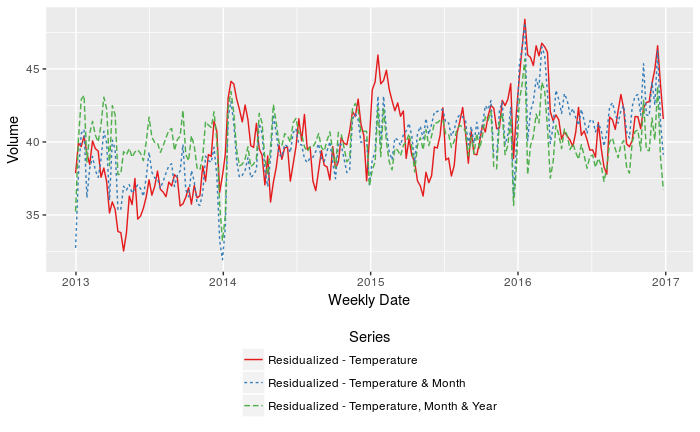

```r
tibble(time=elmarket$time,
                   volume_nortemp_res,
                   volume_nortemp_month_res,
                   volume_nortemp_month_year_res) %>%
    mutate(week=floor_date(time,
                           unit="1 week",
                           week_start = 1)) %>%
    select(-time) %>%
    rename("Residualized - Temperature"=volume_nortemp_res,
           "Residualized - Temperature & Month"=volume_nortemp_month_res,
           "Residualized - Temperature, Month & Year"=volume_nortemp_month_year_res) %>%
    gather(key="Series",value="Volume",-week) %>%
    group_by(week,Series) %>%
    summarize(Volume=mean(Volume)) %>%
    ggplot(aes(x=week,y=Volume,color=Series,linetype=Series)) +
    geom_line() +
    theme(legend.position = "bottom",
          legend.direction = "vertical",
          legend.title.align = 0.5) +
    labs(x="Weekly Date") +
    scale_color_brewer(palette = "Set1")
```

We see that most of the variation in the volume series can be captured by temperature. There is still a fair bit of variation left after this, some of which is a noticable time-trend in volume over time, while some seems to be a systematically higher volume during the first month and a half of the year, as well as some of December. This could be driven by supply factors, as this is a period where hydro reserves are typically still quite high (we need to think carefully about this, though, because the producers take into account expecations about reserves and demand when making their decisions). It could also be the case that controlling for the average temperature across Norway and Sweden does not capture everything, as the peak in the first weeks of 2016 for the series might point to - a period when Eastern Norway and Oslo was unusually cold, while the rest of Norway wasn’t necessarily that cold (this is related to a question of what “controlling for” or “partialling out” something really means - we’re not necessarily capturing everything that has with temperature to do by just a simple measure of temperature).

When adding control for month, we see that the within-year pattern is largely removed. This might mean that we’re capturing supply side factors, that we’re better capturing some of the variation driven by temperature which our average measure is not doing a good job in controlling for, or that there are some separate seasonal effects in demand which is not related to temperature. This is not necessarily important for identifying the price-coefficient, but if we want to forecast the demand curve itself (separate from what happens to supply), this could be important.

When we add controls for year, there is no longer a discernible trend in volumes, though there could still be some within-year trend (which we could test for here, if we wanted to), even though it’s hard to see from the plot.

Even after including these controls, there is still variation in the volumes, which can either be driven by changes in supply, or demand side factors which are still unobserved (we could possibly try to add some from our data, but this is outside of the scope of this exercise).

The main point here is that residualizing and plotting can be an efficient way of learning about the data set, though it doesn’t free us from the need of thinking carefully about what is the right way of understanding the market and the data we have.

#### 7.

We start by estimating the equations and obtaining the residuals.

```r
hydrores_nortemp_fit <- lm(hydrores ~ nortemp,
                     data=elmarket)
hydrores_nortemp_res <- residuals(hydrores_nortemp_fit)
hydrores_nortemp_month_fit <- lm(hydrores ~ nortemp + month,
                               data=elmarket)
hydrores_nortemp_month_res <- residuals(hydrores_nortemp_month_fit)
hydrores_nortemp_month_year_fit <- lm(hydrores ~ nortemp + month + year,
                               data=elmarket)
hydrores_nortemp_month_year_res <- residuals(hydrores_nortemp_month_year_fit)
rm(hydrores_nortemp_fit,hydrores_nortemp_month_fit,hydrores_nortemp_month_year_fit)
```

We now add the average hydrores to the residuals.

```r
meanhydrores <- mean(elmarket$hydrores,na.rm=TRUE)
hydrores_nortemp_res <- hydrores_nortemp_res + meanhydrores
hydrores_nortemp_month_res <- hydrores_nortemp_month_res + meanhydrores
hydrores_nortemp_month_year_res <- hydrores_nortemp_month_year_res + meanhydrores
rm(meanhydrores)
```

Now we can make the plots, beginning with the original series (hydro reservoir variable is missing initially in the sample, so if we do not filter them out, the following code runs but issues a warning).

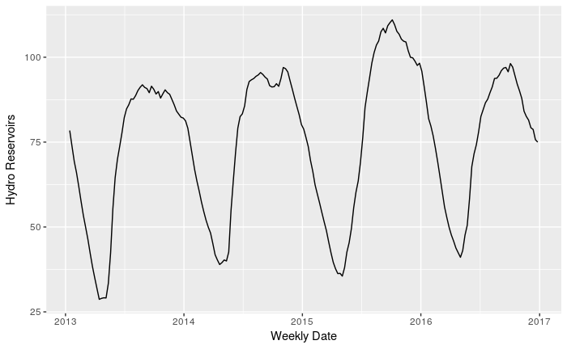

```r
elmarket %>% filter(!is.na(hydrores)) %>%
    mutate(week=floor_date(time,
                           unit="1 week",
                           week_start = 1)) %>%
    group_by(week) %>%
    summarize(hydrores=mean(hydrores)) %>%
    ggplot(aes(x=week,y=hydrores)) +
    geom_line() +
    labs(x="Weekly Date",y="Hydro Reservoirs")
```

```r
NA
```

And now we plot the residualized series.

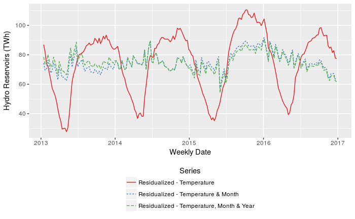

```r
tibble(time=elmarket[!is.na(elmarket$hydrores),]$time,
                   hydrores_nortemp_res,
                   hydrores_nortemp_month_res,
                   hydrores_nortemp_month_year_res) %>%
    mutate(week=floor_date(time,
                           unit="1 week",
                           week_start = 1)) %>%
    select(-time) %>%
    rename("Residualized - Temperature"=hydrores_nortemp_res,
           "Residualized - Temperature & Month"=hydrores_nortemp_month_res,
           "Residualized - Temperature, Month & Year"=hydrores_nortemp_month_year_res) %>%
    gather(key="Series",value="hydrores",-week) %>%
    group_by(week,Series) %>%
    summarize(hydrores=mean(hydrores)) %>%
    ggplot(aes(x=week,y=hydrores,color=Series,linetype=Series)) +
    geom_line() +
    theme(legend.position = "bottom",
          legend.direction = "vertical",
          legend.title.align = 0.5) +
    labs(x="Weekly Date",y="Hydro Reservoirs (TWh)") +
    scale_color_brewer(palette = "Set1")
```

Very little of the total variation in hydro reservoirs can be captured by temperature. There’s a tendency for hydro reserves to be higher when temperature is higher (which explains the changes in the series when residualized with respect to temperature), though it’s not certain what we should think about this. We would believe hydro reservoirs are very sensitive to rain (and also snow, when it melts afterwards), which could also be correlated with temperature (possibly in a very non-straightforward manner). The interesting thing to note here is that this tells us that the variation in volume throughout the year captured by temperature only has a minor effect on the cycle of water in the reservoirs (though it doesn’t mean that the effect of changing volumes is unimportant - just that it is dominated by other factors for the stock). If we rather looked at something like the change in the reservoirs, we would probably see a much clearer link to temperature (stock versus flow).

Month captures a very high share of the variation, which is not surprising when inspecting the plot. Over time, this is driven by the fluctuations in volume (making the increase or decrease change in size), as well as the seasons with typically more or less rain and snow melt.

Controlling for years do not change much here, though it becomes apparent that there has been an increasing trend in water in reservoirs over these years (from comparing the two residualized series). It’s not obvious here that year fundamentally belongs in the supply equation, as this could well capturing an increase in precipitation over the years which was higher than expected, which we would expect to actually have a negative impact on price (everything else equal). (In the same vein, it’s not certain that the change in volume over the years represents a trend in demand, as it could be driven by the lower average prices over the year)

A nice thing to do here, to assess how hydro reservoir stock potentially affects price (at least the covariation), would be to show the series of prices residualized with the same variables, and see whether the result is as expected. (Feel free to do this - one residualized series for price and one for hydrores, e.g., with respect to temperature, month and year. You should see a pattern where prices tend to be lower, the larger the residual water stock is.)

A further comment: You might notice the seeming negative autocorrelation pattern in this series, where reservoir either decreases before jumping up or vice versa, this is driven by subtracting the monthly averages, while hydro reservoir is measured weekly. In months where the stock is decreasing, we will tend to see a decrease throughout the month, while in months where the stock is increasng, we will see the opposite pattern. Controlling for the week would remove this (e.g., dummy for each week number of the year).

### Estimating supply and demand

#### 8.

We need to generate a factor varialbe for hours of the day.

```r
elmarket <- elmarket %>%
    mutate(hour=factor(hour(time)))
```

We estimate a few different specifications here and discuss them to understand what is going on. Here we use the `summary` function to get a more compact table of results.

```r
supply_iv_hourcont <- ivreg(volume ~ price + hydrores + hour + month + year |
                                    nortemp + swetemp + hydrores + hour + month + year,
                                data=elmarket)
summary(supply_iv_hourcont)
```

```
Call:
ivreg(formula = volume ~ price + hydrores + hour + month + year |
    nortemp + swetemp + hydrores + hour + month + year, data = elmarket)

Residuals:
      Min        1Q    Median        3Q       Max
-140.5804   -3.0966   -0.1146    3.0811   22.1540

Coefficients:
              Estimate Std. Error t value Pr(>|t|)
(Intercept) -12.311120   0.957851 -12.853  < 2e-16 ***
price         0.902506   0.015255  59.161  < 2e-16 ***
hydrores      0.228729   0.005467  41.836  < 2e-16 ***
hour1        -0.200756   0.190737  -1.053  0.29257
hour2        -0.174940   0.191573  -0.913  0.36116
hour3        -0.076121   0.191833  -0.397  0.69151
hour4         0.022635   0.191260   0.118  0.90579
hour5         0.573514   0.190290   3.014  0.00258 **
hour6         2.421145   0.192462  12.580  < 2e-16 ***
hour7         3.180512   0.203270  15.647  < 2e-16 ***
hour8         3.155813   0.211879  14.894  < 2e-16 ***
hour9         3.829943   0.209576  18.275  < 2e-16 ***
hour10        4.428225   0.206180  21.477  < 2e-16 ***
hour11        4.670010   0.203336  22.967  < 2e-16 ***
hour12        4.670235   0.200494  23.294  < 2e-16 ***
hour13        4.600218   0.198830  23.136  < 2e-16 ***
hour14        4.601455   0.197664  23.279  < 2e-16 ***
hour15        4.572303   0.197905  23.104  < 2e-16 ***
hour16        4.405136   0.200238  22.000  < 2e-16 ***
hour17        4.141080   0.205742  20.128  < 2e-16 ***
hour18        4.397106   0.205274  21.421  < 2e-16 ***
hour19        4.746663   0.200954  23.621  < 2e-16 ***
hour20        4.490258   0.197042  22.788  < 2e-16 ***
hour21        3.859605   0.194935  19.799  < 2e-16 ***
hour22        2.900012   0.192764  15.044  < 2e-16 ***
hour23        1.760176   0.190596   9.235  < 2e-16 ***
month2        5.743554   0.194863  29.475  < 2e-16 ***
month3        5.855548   0.249888  23.433  < 2e-16 ***
month4        3.419142   0.304871  11.215  < 2e-16 ***
month5        0.870353   0.319446   2.725  0.00644 **
month6       -4.479294   0.234943 -19.065  < 2e-16 ***
month7       -9.296996   0.192406 -48.320  < 2e-16 ***
month8      -12.564044   0.165941 -75.714  < 2e-16 ***
month9      -13.532485   0.158113 -85.587  < 2e-16 ***
month10     -11.174327   0.154327 -72.407  < 2e-16 ***
month11      -7.813950   0.151478 -51.585  < 2e-16 ***
month12      -0.855418   0.152758  -5.600 2.16e-08 ***
year2014      8.382495   0.142609  58.780  < 2e-16 ***
year2015     17.134135   0.255367  67.096  < 2e-16 ***
year2016     13.748728   0.175219  78.466  < 2e-16 ***
---
Signif. codes:  0 ‘***’ 0.001 ‘**’ 0.01 ‘*’ 0.05 ‘.’ 0.1 ‘ ’ 1

Residual standard error: 5.12 on 34708 degrees of freedom
Multiple R-Squared: 0.5847, Adjusted R-squared: 0.5843
Wald test:  1833 on 39 and 34708 DF,  p-value: < 2.2e-16
```

Note that not controlling for hour weakens the relationship between price and volume. This is related to an issue we saw before, that volume is driven by temperature, but also varies across the hours of the day (due to the natural reasons), while temperature also varies across the hours of the day in a very predictable fashion that is quite correlated with the low-period during the night. That means we have an endogeneity problem when not including hours. This is a good example of a violation of exogeneity, rather than exclusion. Temperature most likely doesn’t have a direct effect on supply, and should really be excluded, while it might fail on exogeneity due to correlation with unobserved factors affecting supply. This is a somewhat tricky example, at least if we believe hour of the day is actually excluded from supply (following the argument below). The reason for the problem is that if hour is included neither as a control (something we believe will have a direct effect on supply), nor as an instrument (something we believe will affect supply through it’s effect on price), then it will be left in unobserved factors. Since it does have an effect on supply (possibly only through it’s effect on demand), then we will have an omitted variable problem (since it is correlated with our instruments).

```r
supply_iv_nohour <- ivreg(volume ~ price + hydrores + month + year |
                                    nortemp + swetemp + hydrores + month + year,
                                data=elmarket)
stargazer(supply_iv_nohour, supply_iv_hourcont,
          type='html',
          omit = 'hour', omit.labels = c('Hour FE'),
          digits=2,
          keep.stat = c('n', 'rsq'))
```

|  | *Dependent variable:* |  |
| --- | --- | --- |
|  | volume |  |
|  | (1) | (2) |
| price | 0.20*** | 0.90*** |
|  | (0.03) | (0.02) |
| hydrores | 0.07*** | 0.23*** |
|  | (0.01) | (0.01) |
| month2 | 0.12 | 5.74*** |
|  | (0.26) | (0.19) |
| month3 | -2.03*** | 5.86*** |
|  | (0.35) | (0.25) |
| month4 | -6.36*** | 3.42*** |
|  | (0.43) | (0.30) |
| month5 | -10.27*** | 0.87*** |
|  | (0.48) | (0.32) |
| month6 | -13.01*** | -4.48*** |
|  | (0.36) | (0.23) |
| month7 | -15.46*** | -9.30*** |
|  | (0.27) | (0.19) |
| month8 | -15.76*** | -12.56*** |
|  | (0.19) | (0.17) |
| month9 | -14.51*** | -13.53*** |
|  | (0.15) | (0.16) |
| month10 | -10.88*** | -11.17*** |
|  | (0.14) | (0.15) |
| month11 | -6.84*** | -7.81*** |
|  | (0.14) | (0.15) |
| month12 | -3.69*** | -0.86*** |
|  | (0.17) | (0.15) |
| year2014 | 2.92*** | 8.38*** |
|  | (0.23) | (0.14) |
| year2015 | 5.95*** | 17.13*** |
|  | (0.45) | (0.26) |
| year2016 | 6.56*** | 13.75*** |
|  | (0.29) | (0.18) |
| Constant | 33.64*** | -12.31*** |
|  | (1.72) | (0.96) |
| Hour FE | No | Yes |
| Observations | 34,748 | 34,748 |
| R<sup>2</sup> | 0.66 | 0.58 |
| *Note:* | p<0.1; p<0.05; p<0.01 |  |

This does not mean that the hour of the day actually belongs in the supply function. There is no reason to believe that costs in power production are changing noticably during the day, since it’s not sensitive to temperature, and the changes in the shadow value of water within a day should be small. Labor costs could be higher during odd hours, but it is highly unlikely that this feeds into any marginal production decisions in this capital intensive process. Controlling for hour in this way (if it’s actually excluded) will make us attribute shifts in the demand curve to the supply curve, though this should not necessarily have an impact on the estimated slope. The difference in the slope estimate when changing the instrument set should make us worried. Note that a reason for why the price-parameter estimate changes when you include hour as an instrument rather than a control, could be due to functional form. The changes we see in demand from hourly changes could cause shifts along the supply curve where the slope is on average different, than the average slope of supply in the different points we visit as the demand curve shifts due to temperature. This could potentially be tested, for instance by looking at whether the slope of price is different across the hours (using temperature in each hour as an instrument - note: requires that the instrument is uncorrelated with unobserved factors every hour), though this is outside the scope of this exercise.

```r
supply_iv_hourinst <- ivreg(volume ~ price + hydrores + month + year |
                                    nortemp + swetemp + hydrores + hour + month + year,
                                data=elmarket)
stargazer(supply_iv_hourinst,
          type='text',
          digits=2,
          omit = c('month', 'year'), omit.labels = c('Month FE', 'Year FE'),
          notes = c("Instruments: Temperature in Norway and Sweden,", "and indicators for hour of day"),
          notes.align = 'l',
          keep.stat = c('n', 'rsq'))
```

```
===========================================================
                          Dependent variable:
             ----------------------------------------------
                                 volume
-----------------------------------------------------------
price                           1.34***
                                 (0.01)

hydrores                        0.33***
                                 (0.01)

Constant                       -36.25***
                                 (0.97)

-----------------------------------------------------------
Month FE                          Yes
Year FE                           Yes
-----------------------------------------------------------
Observations                     34,748
R2                                0.08
===========================================================
Note:        *p<0.1; **p<0.05; ***p<0.01
             Instruments: Temperature in Norway and Sweden,
             and indicators for hour of day
```

We can also calculate the elasticity of supply with respect to price at the average volume and price in the sample:

```r
supply_iv_hourinst$coefficients[["price"]]*mean(elmarket$price)/mean(elmarket$volume)
```

```
[1] 0.971141
```

#### 9.

We choose to control for temperature, hour, month and year. Temperature and hour seem very likely to be included in demand, while month and year are arguably not excluded (additional seasonal effects, and increases in demand over time). The hydro reservoir instrument will then only utilize the variation left after partialling out the included variables (the controls works the same way as in ordinary regression, also when considering their impact on the instrument).

```r
demand_iv <- ivreg(volume ~ price + nortemp + swetemp + hour + month + year |
                       hydrores + nortemp + swetemp + hour + month + year,
                   data=elmarket)
```

We can now calculate the elasticity of demand with respect to price at average volume and price:

```r
demand_iv$coefficients[["price"]]*mean(elmarket$price)/mean(elmarket$volume)
```

```
[1] -0.126084
```

We see that demand is very inelastic (far below one in elasticity).

Lastly, we make a table with the estimated demand and supply functions keeping only the coefficients of interest (note that what “is of interest” depends on the application, and one could very well be interested in some of the time-coefficients).

```r
stargazer(demand_iv,supply_iv_hourinst,
          type = "html",
          style = "aer",
          digits = 2,
          covariate.labels = c("Price","Temperature Norway",
                               "Temperature Sweden","Hydro Reservoirs"),
          dep.var.labels = c("Volume"),
          column.labels = c("(Demand)","(Supply)"),
          omit = c("hour","month","year"),
          omit.labels = c("Hour FE","Month FE","Year FE"),
          keep.stat=c("n","rsq"))
```

|  | Volume |  |
| --- | --- | --- |
|  | (Demand) | (Supply) |
|  | (1) | (2) |
| Price | -0.17*** | 1.34*** |
|  | (0.01) | (0.01) |
| Temperature Norway | -0.30*** |  |
|  | (0.01) |  |
| Temperature Sweden | -0.33*** |  |
|  | (0.01) |  |
| Hydro Reservoirs |  | 0.33*** |
|  |  | (0.01) |
| Constant | 46.71*** | -36.25*** |
|  | (0.55) | (0.97) |
| Hour FE | Yes | No |
| Month FE | Yes | Yes |
| Year FE | Yes | Yes |
| Observations | 34,748 | 34,748 |
| R<sup>2</sup> | 0.80 | 0.08 |
| *Notes:* | ***Significant at the 1 percent level. |  |
|  | **Significant at the 5 percent level. |  |
|  | *Significant at the 10 percent level. |  |

Up until this point we have used default standard errors, which are likely not valid as explained in the lecture. We will now show a few examples of how we can obtain alternative estimates of standard errors. We will do this for the supply equation.

We use functions from the ivpack package to compute the enw standard errors. First we calculate heteroscedasticity robust standard errors:

```r
library(ivpack)
robust <- robust.se(supply_iv_hourinst)
```

```
[1] "Robust Standard Errors"
```

We can also calculate cluster robust standard errors. Clustering of residuals basically allows the residuals to have arbitrary correlation within a cluster (any form of autocorrelation and heteroskedasticity, but only within the cluster). Choose a quite “aggressive” clustering, by letting errors be correlated in any way within each week of the sample (not week number of the year, but week by week):

```r
elmarket <- elmarket %>%
    mutate(week=floor_date(time,
                    unit="1 week",
                    week_start = 1))
cluster <- cluster.robust.se(supply_iv_hourinst,elmarket[!is.na(elmarket$hydrores),]$week)
```

```
[1] "Cluster Robust Standard Errors"
```

Note that this assumes that there is no correlation between clusters, which doesn’t necessarily fit the structure of the dataset too well, but this example is mostly for illustration.

For comparison, we can make a new table where we compare the different standard errors:

```r
stargazer(supply_iv_hourinst,supply_iv_hourinst,supply_iv_hourinst,
          type="html",
          digits = 2,
          omit = c("hour","month","year"),
          omit.labels = c("Hour FE","Month FE","Year FE"),
          covariate.labels = c("Price","Hydro Reservoirs"),
          dep.var.labels = c("Volume"),
          column.labels = c("Default","Robust","Clustered"),
          keep.stat=c("n","rsq"),
          se=list(NULL,robust[,2],cluster[,2])) #The standard errors are stored in the second column of the coeftest objects
```

|  | *Dependent variable:* |  |  |
| --- | --- | --- | --- |
|  | Volume |  |  |
|  | Default | Robust | Clustered |
|  | (1) | (2) | (3) |
| Price | 1.34*** | 1.34*** | 1.34*** |
|  | (0.01) | (0.02) | (0.10) |
| Hydro Reservoirs | 0.33*** | 0.33*** | 0.33*** |
|  | (0.01) | (0.01) | (0.07) |
| Constant | -36.25*** | -36.25*** | -36.25*** |
|  | (0.97) | (1.22) | (7.52) |
| Hour FE | No | No | No |
| Month FE | Yes | Yes | Yes |
| Year FE | Yes | Yes | Yes |
| Observations | 34,748 | 34,748 | 34,748 |
| R<sup>2</sup> | 0.08 | 0.08 | 0.08 |
| *Note:* | p<0.1; p<0.05; p<0.01 |  |  |

We see that the standard errors become substantially larger once we move away from the default.

#### 10.

We use the functions stat_summary_bin to plot average values of volume for 100 temperature bins. We also add a linear fit to the plot to clarify whether or not the relationship seems linear.

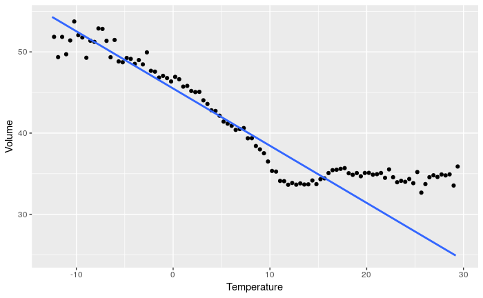

```r
ggplot(data=elmarket,aes(x=nortemp,y=volume)) +
    stat_summary_bin(fun.y="mean",bins=100,geom=c("point")) +
    geom_smooth(method="lm",se = FALSE) +
    labs(x="Temperature",y="Volume")
```

When assessing instruments, where we will often add a linear specification of the instrument (at least as a start), which means that this can be useful for assessing how appropriate a linear specification is. In this case, there’s some apparent deviations from a linear relationship from temperatures higher than 10 degrees. This should make us think hard about why that is, and not - as some are tempted to do - try to find another functional form for the relationship which will fit better in a statistical sense (at least before we are sure about the underlying causes creating the deviation from linearity). This doesn’t mean that we’re always seeking linearity, but we should be sure that non-linearities are due to a causal relationship, and not driven by omitted variable bias.

From what we’ve seen earlier, the hour of the day is correlated with both volume and temperature in a very specific way (and is actually the major cause of the non-linearity after 10 degrees).

We now plot the same relationship after residualizing the variables with respect to hour of the day. In this case we specify how we want to obtain the residuals within the ggplot function, but we could also have obtained the residuals in a separate step and given them as an argument to ggplot.

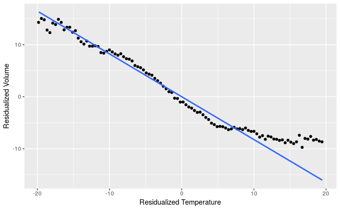

```r
ggplot(data=elmarket,
       aes(x=residuals(lm(nortemp ~ hour,
                          data=elmarket)),
           y=residuals(lm(volume ~ hour,
                          data=elmarket)))) +
    stat_summary_bin(fun.y="mean",bins=100,geom="point") +
    geom_smooth(method="lm",se=FALSE) +
    labs(x="Residualized Temperature",y="Residualized Volume")
```

We see that “partialling out” hour gives us a relationship which seems to be closer to linear, and it is also very “tight” (no large jumps in the y-value from one consecutive bin to another - this is to some extent driven by the relatively large amount of observations in this data set, but also the fact that the relationship between temperature and volume is very strong). If this was the only plot we relied on to assess how to enter temperature into the demand equation, we would have little reason to use another functional relation than the standard linear.

The deviations from linear becomes even smaller (in an absolute sense) if we also add other time-controls from the demand equation above:

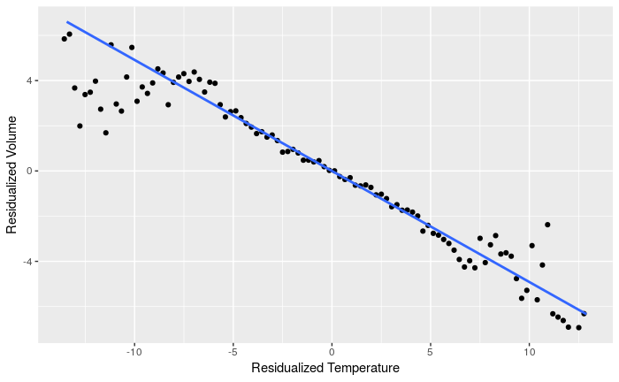

```r
ggplot(data=elmarket,
       aes(x=residuals(lm(nortemp ~ hour + month + year,
                          data=elmarket)),
           y=residuals(lm(volume ~ hour + month + year,
                          data=elmarket)))) +
    stat_summary_bin(fun.y="mean",bins=100,geom="point") +
    geom_smooth(method="lm",se=FALSE) +
    labs(x="Residualized Temperature",y="Residualized Volume")
```

It is useful to note that the range of the x-axis becomes quite a bit narrower when adding the additional time controls (This is also a nice illustration of what control variables do, i.e., removing variation in “all” variables of interest, here for both temperature and volume).

Now we go through the same steps for price.

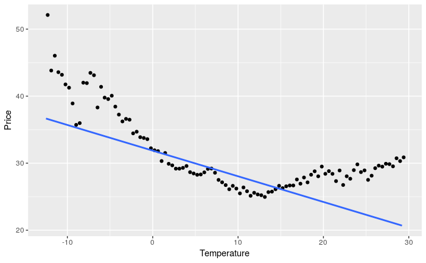

```r
ggplot(data=elmarket,aes(x=nortemp,y=price)) +
    stat_summary_bin(fun.y="mean",bins=100,geom=c("point")) +
    geom_smooth(method="lm",se = FALSE) +
    labs(x="Temperature",y="Price")
```

Looking at the relationship between price and temperature is basically doing a visual inspection of the first stage. Without controls, seems to suggest a quite non-linear relationship (Note that when we talk about “non-linear” v.s. “linear” in regressions, it is a statement about the conditional expectation function, which is what such “bin and scatter” strategies show us an approximation of. If you were to do the raw scatter, there is a lot of variation around the expectation. Though we would like to capture as much of this as possible, everything else equal, it’s somewhat separate from our first order concern: “Are we getting what we need?”)

We now plot the same relationship after residualizing with respect to hour of the day.

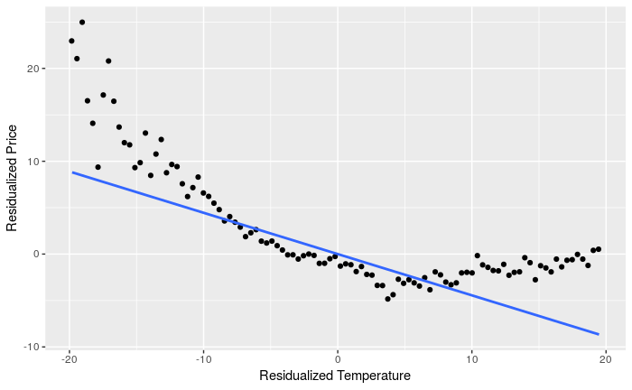

```r
ggplot(data=elmarket,
       aes(x=residuals(lm(nortemp ~ hour,
                          data=elmarket)),
           y=residuals(lm(price ~ hour,
                          data=elmarket)))) +
    stat_summary_bin(fun.y="mean",bins=100,geom="point") +
    geom_smooth(method="lm",se=FALSE) +
    labs(x="Residualized Temperature",y="Residualized Price")
```

We see that the relationship still displays quite strong non-linearities. Still, resist the temptation to do this:

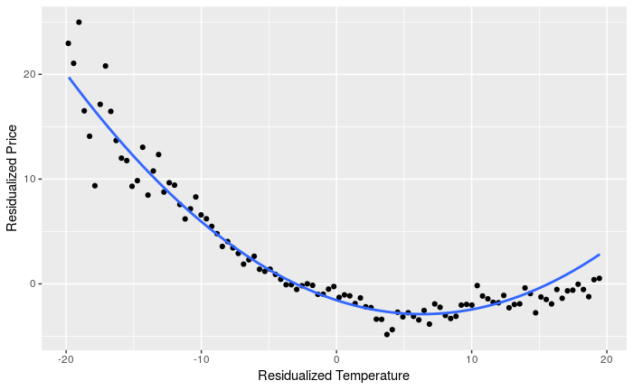

```r
ggplot(data=elmarket,
       aes(x=residuals(lm(nortemp ~ hour,
                          data=elmarket)),
           y=residuals(lm(price ~ hour,
                          data=elmarket)))) +
    stat_summary_bin(fun.y="mean",bins=100,geom="point") +
    geom_smooth(method="lm",
                formula=y ~ poly(x,2),
                se=FALSE) +
    labs(x="Residualized Temperature",y="Residualized Price")
```

which fits a quadratic specification. It fits better, but that doesn’t mean that it’s the correct relationship from a causal perspective. Rather, check what happens if we residualize more extensively:

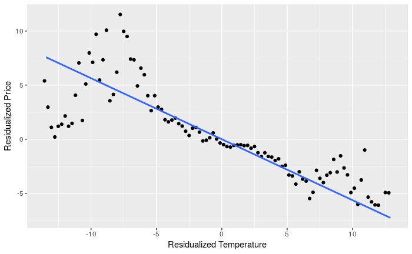

```r
ggplot(data=elmarket,
       aes(x=residuals(lm(nortemp ~ hour + month + year,
                          data=elmarket)),
           y=residuals(lm(price ~ hour + month + year,
                          data=elmarket)))) +
    stat_summary_bin(fun.y="mean",bins=100,geom="point") +
    geom_smooth(method="lm",se=FALSE) +
    labs(x="Residualized Temperature",y="Residualized Price")
```

This seems better, and furthermore, we expect there to be important drivers of price, at least over months (picking up season), which is correlated with temperature in a way which is not necessarily telling us about how price is changing as shifts in the demand curve due to temperature moves us along the supply curve (the first stage interpretation we desire in this case).

To be completely in line with this interpretation, we should actually control for any variable we believe are not excluded from the supply function, such as hydro reservoirs. Doing this with such a binned scatterplot is easy enough, but we will look further into a proper Visual IV plot below.

#### 11.

##### (a)

We begin with volume and price.

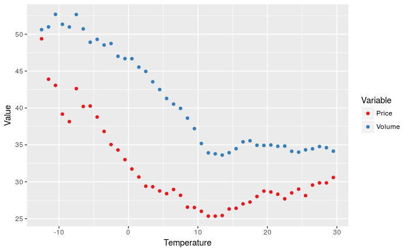

```r
elmarket %>%
    select(nortemp,price,volume) %>%
    rename("Price"=price,"Volume"=volume) %>%
    mutate(Volume=Volume) %>%
    gather(key="Variable",value="Value",-nortemp) %>%
ggplot(aes(x=nortemp,y=Value,color=Variable)) +
        stat_summary_bin(fun.y="mean",binwidth=1,geom="point") +
    scale_color_brewer(palette = "Set1") +
    labs(x="Temperature")
```

And now the number of observations in each bin:

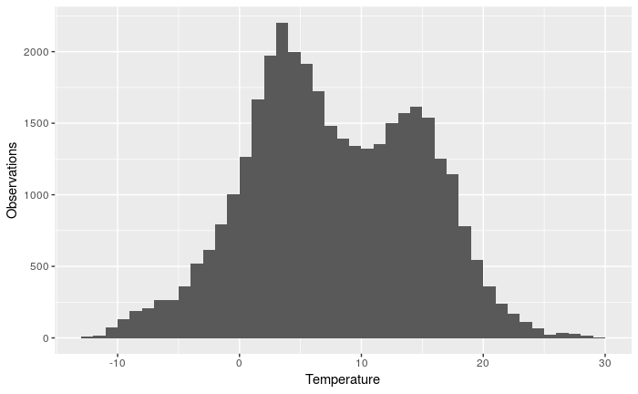

```r
ggplot(data=elmarket,aes(x=nortemp,y=volume)) +
    stat_summary_bin(fun.y=function(y) length(y),binwidth=1,geom="col") +
    labs(x="Temperature",y="Observations")
```

Lastly we plot average volume and price against each other:

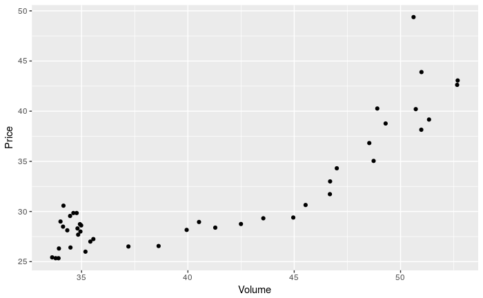

```r
elmarket %>%
    mutate(tempbin=cut_width(nortemp,width=1,boundary=-13)) %>%
    group_by(tempbin) %>%
    summarize(meanvolume=mean(volume),
              meanprice=mean(price)) %>%
    ggplot(aes(x=meanvolume,y=meanprice)) +
    geom_point() +
    labs(x="Volume",y="Price")
```

From these plots, we see that the relationships do not look too bad. All the way up to 10 degrees temperature, both price and volume tend to fall, while they show a weak increase afterwards. If we believed there were no problems with omitted variables here, this would be encouraging in the sense of showing that the IV basically does the right thing. From the arguments in 10., we know that there are quite likely issues with omitted variables here (which we will take care of below - at least for the ones we can observe), and it thus serves as a nice example of the limits to what we can hope to learn from the VIV plot.

There are some deviations, particularly for very low temperatures, but if we look at the small number of observations in these bins, we should expect more “noise” there. The plot for price is showing us the basis for the first stage in a more refined manner than just regressing price on temperature, such that we can consider both functional form issues, if the relationship is as we expect, and how noisy or stable it seems to be (here the relationship doesn’t look particularly noisy, though this is often a function of how many observations we have in each bin). The plot for volume is showing us the reduced form - the basis for a regression of the dependent variable on the instrument. If we believe exogeneity and the exclusion restriction, this shows us the change in volume that is induced by temperature, through its effect on prices. If the “first stage”-plot is easy to interpret, we can basically guess how the VIV-plot (volume versus price as averages within bins of temperatures) will look like, so this is not necessarily as important as the two other plots, but can be useful to consider to see whether the instrument moves the dependent variable as it should, if it’s actually working through price.

One could calculate the standard error of the mean estimate within each bin and add error bars to formally show how uncertain we should consider the pattern in the plot. Below is a coded example of this.

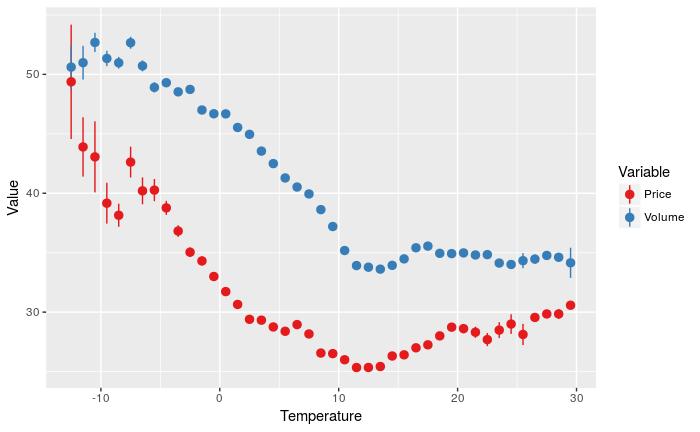

```r
elmarket %>%
    select(nortemp,price,volume) %>%
    rename("Price"=price,"Volume"=volume) %>%
    mutate(Volume=Volume) %>%
    gather(key="Variable",value="Value",-nortemp) %>%
ggplot(aes(x=nortemp,y=Value,color=Variable)) +
        stat_summary_bin(fun.data="mean_se",binwidth=1,geom="pointrange") +
    scale_color_brewer(palette = "Set1") +
    labs(x="Temperature")
```

The plot of price against volume, where each point represents the average within a temperature bin, basically shows us the relationship between the when “filtered” through temperature (the covariation in them when we think about temperature shifting them around simultaneously). This can be thought of as showing the basis for the IV estimates themselves, and is a nice way to visualize this relationship, and also assess functional form, whether the instrument seems to be doing the right thing, and how noisy/stable the relationship is. We are fine with seeing some “clouds” of points in this plot (such as in the lower left corner), but we would not like to see a clear U-shape or something similar, since that would seem to be against the intuition that we’re estimating a supply curve (unless we have a very good explanation or intuition for why this should be so in the particular market we’re studying).

It should be noted that these plots do not tell us anything about exogeneity or the exclusion restriction in themselves, though, coupled with other things we know, either on the specific market or from theory we think applies here, we could potentially detect worrisome features pointing to a violation of the main assumptions of the IV estimator. Otherwise, the plots should be viewed as a practical, graphical device for assessing functional form and how well the IV works (note again that this is condtional on the main assumptions - exogeneity and exclusion - actually holding for the instrument).

##### (b)

We begin by residualizing the variables with respect to hour, month, year and hydrores:

```r
nortemp_res <- residuals(lm(nortemp ~ hour + month + year + hydrores,
                            data=elmarket)) + mean(elmarket$nortemp,na.rm=TRUE)
price_res <- residuals(lm(price ~ hour + month + year + hydrores,
                            data=elmarket)) + mean(elmarket$price,na.rm=TRUE)
volume_res <- residuals(lm(volume ~ hour + month + year + hydrores,
                            data=elmarket)) + mean(elmarket$volume,na.rm=TRUE)
```

Here it is important to note that there are 312 missing values in hydrores:

```r
sum(is.na(elmarket$hydrores))
```

```
[1] 312
```

Because we are residualizing with respect to hydrores this means that we will have missing values in the residualized variables in the rows where hydrores is missing. We handle this by subsetting the dataset to only include rows where hydrores is not missing.

```r
elmarket_subs <- elmarket %>%
    filter(!is.na(hydrores))
```

We can now include the residualized variables in the subset data.

```r
elmarket_subs <- cbind(elmarket_subs,nortemp_res,price_res,volume_res)
```

We also need to note that the range of the residualized temperature is much smaller:

```r
range(nortemp_res)
```

```
[1] -5.577507 20.847848
```

We now make the plots:

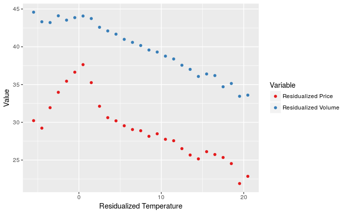

```r
elmarket_subs %>%
    select(nortemp_res,price_res,volume_res) %>%
    mutate(volume_res=volume_res) %>%
    rename("Residualized Price"=price_res,"Residualized Volume"=volume_res) %>%
    gather(key="Variable",value="Value",-nortemp_res) %>%
ggplot(aes(x=nortemp_res,y=Value,color=Variable)) +
        stat_summary_bin(fun.y="mean",binwidth=1,geom="point") +
    scale_color_brewer(palette = "Set1") +
    labs(x="Residualized Temperature")
```

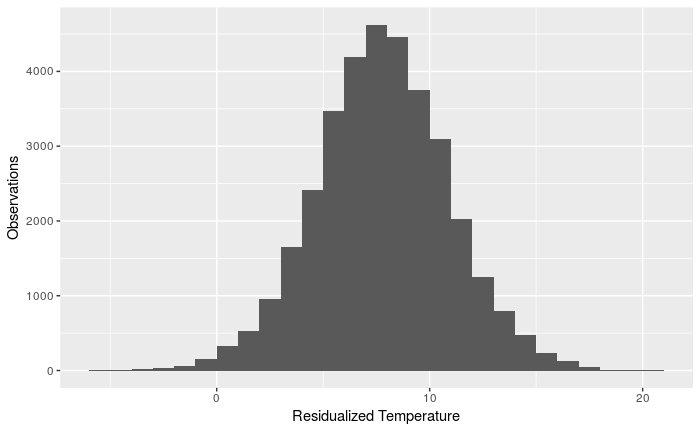

```r
ggplot(data=elmarket_subs,aes(x=nortemp_res,y=volume_res)) +
    stat_summary_bin(fun.y=function(y) length(y),binwidth=1,geom="col") +
    labs(x="Residualized Temperature",y="Observations")
```

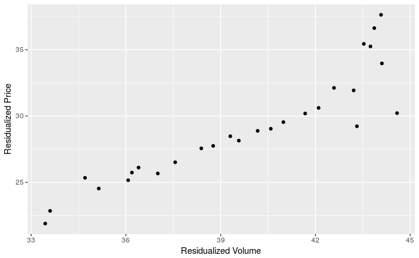

```r
elmarket_subs %>%
    mutate(tempbin=cut_width(nortemp_res,width=1,boundary=-6)) %>%
    group_by(tempbin) %>%
    summarize(meanvolume=mean(volume_res),
              meanprice=mean(price_res)) %>%
    ggplot(aes(x=meanvolume,y=meanprice)) +
    geom_point() +
    labs(x="Residualized Volume",y="Residualized Price")
```

We see that there is no longer a “flattening out” at the end of either prices or volumes towards higher temperatures (which is due to controlling for hour of the day). The relationships are quite linear for most of the schedule, though for temperatures below zero degrees, prices seem to be increasing with higher temperature. Inspecting the bars showing the number of observations within each bin tells us that we have few observations here, and that these estimates should be treated as more uncertain (in the statistical sense). Still, it could be an indication that there are some important factors we are not picking up. Since this pattern wasn’t apparent before we residualized, in practice we would have done a few more plots to see which control is responsible for generating this (mostly it comes from controlling for month, which could tell us that we’re missing some important control in the supply relation, maybe relating to precipitation or inflow into the reservoirs (as opposed to the stocks we observe)).

The scatter of average volume against prices might seem a bit better than before, but the main improvement is that we believe that some of the controls were necessary for taking care of some worries with the exogeneity of the instrument (e.g., the correlation between hour of the day and temperature). Even though the pattern in this plot might seem to suggest some deviation from linearity, it doesn’t give us a lot of hope that we’ll be able to rule out linearity compared to some other, more flexible functional form (this would have to come from some well-founded belief we have about this market, if we were to go for something else).